# Heart rate recovery analysis

Application of Bayesian Non-Linear Mixed effect models

Author

Nicoló Foppa Pedretti

## 1 Introduction

The advent of wearable technology, such as heart rate watches, has revolutionized the way individuals monitor and optimize their fitness and health. These devices provide continuous, real-time data on heart rate, offering valuable insights into cardiovascular responses during and after physical activity. This analysis aims to model the heart rate decrease following a standardized workout, a key indicator of cardiovascular recovery and fitness level. By leveraging heart rate data, we seek to understand how factors such as the number of training sessions in the past two weeks influence the rate of heart rate recovery. This study will explore the interplay between training frequency and recovery dynamics, providing a foundation for personalized fitness recommendations and enhanced training protocols. Through statistical modeling, we aim to uncover patterns that can inform athletes, coaches, and fitness enthusiasts about optimizing workout regimens for improved performance and health outcomes.

## 3 Statistical model

The NLME model can be expressed as follows:

$$y_{ij} = f(x_{ij}, \boldsymbol{\beta}, \boldsymbol{b}_i) + \epsilon_{ij}$$

where:

- $y_{ij}$: Heart rate measurement for individual $i$ at time point $j$,
- $f(x_{ij}, \boldsymbol{\beta}, \boldsymbol{b}_i)$: Non-linear function describing the heart rate recovery trajectory, dependent on time $x_{ij}$, fixed effect parameters $\boldsymbol{\beta}$, and individual-specific random effects $\boldsymbol{b}_i$,
- $\boldsymbol{b}_i \sim N(0, \boldsymbol{\Psi})$: Random effects vector, assumed to follow a multivariate normal distribution with covariance matrix $\boldsymbol{\Psi}$,
- $\epsilon_{ij} \sim N(0, \sigma^2)$: Residual error, assumed to be normally distributed with variance $\sigma^2$.

The negative exponential shape function was chosen because heart rate recovery typically exhibits a rapid initial decline followed by a slower stabilization, a pattern well-captured by this form. Peer-reviewed studies in exercise physiology support its use, as it effectively models the physiological process of cardiovascular recovery. Additionally, its parameters allow interpretable insights into amplitude, decay rate, and asymptotic heart rate, aligning with the data’s non-linear dynamics. The model for heart rate recovery is specified as:
$$y_{ij} = a_i \cdot \exp(-b_i \cdot t_{ij}) + k + \epsilon_{ij}$$
where:

- $y_{ij}$: heart rate measurement for session $i$ at time point $j$
- $t_{ij}$: time since the end of the workout for session $i$ at measurement $j$
- $a_i = \alpha_0 + \alpha_1 \cdot \text{training}_i + u_i$: amplitude parameter for session $i$, with $\alpha_0$ as the fixed intercept, $\alpha_1$ as the fixed effect of the number of training sessions in the previous two weeks ($\text{training}_i$), and $u_i \sim N(0, \sigma_u^2)$ as the random intercept for session $i$
- $b_i = \beta_0 + \beta_1 \cdot \text{training}_i + v_i$: decay rate parameter for session $i$, with $\beta_0$ as the fixed intercept and $\beta_1$ as the fixed effect of the number of training sessions in the previous two weeks ($\text{training}_i$), and $v_i \sim N(0, \sigma_u^2)$ as the random intercept for session $i$
- $k$: Asymptotic heart rate, assumed constant across sessions,
- $\epsilon_{ij} \sim N(0, \sigma^2)$: residual error, assumed normally distributed with variance $\sigma^2$

This model captures the non-linear heart rate recovery trajectory, incorporating the effect of training frequency as a fixed effect and session-specific variability through a random intercept.

## 4 R code

To analyze the heart rate recovery data and model the non-linear decrease following the standardized treadmill workout, we will utilize the R programming environment in conjunction with the `brms` package, which interfaces with Stan for Bayesian statistical modeling. This approach enables robust fitting of the non-linear mixed effects model, leveraging Stan’s powerful Markov Chain Monte Carlo (MCMC) sampling to estimate model parameters while accounting for both fixed and random effects. The brms package provides a user-friendly framework to specify complex models, incorporate covariates such as the number of training sessions in the past two weeks, and handle the hierarchical structure of the data efficiently. See [6].

We load useful R libraries to handle data and bayesian model:

```r
library(data.table)
library(gridExtra)
library(bayesplot)
library(cmdstanr)
library(ggplot2)
library(arrow)
library(brms)
```

We visualize the experimental data that are used for the statistical model

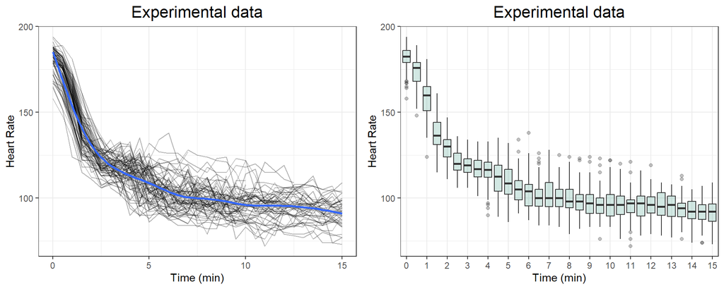

```r
dt_test = read_parquet("dataset.parquet")
t1 = ggplot(dt_test) +
  geom_line(aes(x = time, y = hr, group = date), alpha = 0.3) +
  geom_smooth(aes(x = time, y = hr)) +
  labs(title = "Experimental data") +
  ylab("Heart Rate") + xlab("Time (min)") +
  theme_bw() +
  theme(plot.title = element_text(hjust = 0.5, size = 16))

t2 = ggplot(dt_test) +
  geom_boxplot(aes(x = as.factor(time), y = hr), fill = "#69b3a2",alpha = 0.3) +
  labs(title = "Experimental data") +
  scale_x_discrete(breaks = seq(0,15)) +
  ylab("Heart Rate") + xlab("Time (min)") +
  theme_bw() +
  theme(plot.title = element_text(hjust = 0.5, size = 16))

grid.arrange(t1,t2,ncol = 2)
```

In this block we have the code for the bayesian no-linear mixed effect model. We leverage STAN bayesian framework through `brms` package. The coefficient $b$ need to be positive (in order to have $-b$ always negative) but the intercept and coefficient of $\text{training}_i$ can be positive or negative, for this reason we estimate the $log(b)$ and then we exponentiate the variable `logb` to get our final results. We select priors and the initial points based on literature and data observations.

```r
fit_exponential <- brms::brm(
  formula = brms::bf(hr ~ a * exp(-exp(logb) * time) + k,
                     a + logb ~ 1 + N_train + (1 | date),
                     k ~ 1,
                     nl=TRUE),
  data = dt_test,
  cores = 4,
  backend = "cmdstan",
  init = replicate(4,list(b_a_Intercept = 95       # Fixed intercept for a
                          ,b_a_N_train = 0         # Effect of N_train on a
                          ,b_b_Intercept = 0
                          ,b_b_N_train = 0
                          ,b_k_Intercept = 90
                          ),
                   simplify = F),
  seed = 85538,
  prior   = c(prior(normal(96,1), nlpar = "a", coef="Intercept"),
              prior(normal(0,1), nlpar = "a", coef="N_train"),
              prior(normal(0,1), nlpar = "logb", coef="Intercept"),
              prior(normal(0,1), nlpar = "logb", coef="N_train"),
              prior(normal(90,1), nlpar = "k", lb = 0)),
  control = list(adapt_delta = 0.99,
                 max_treedepth = 15),
  file = "nlme_gps/fit_exp_re_cov.rds"
)
```

Let’s see the results of the analysis

```r
fit_exponential
```

```
 Family: gaussian
  Links: mu = identity; sigma = identity
Formula: hr ~ a * exp(-exp(logb) * time) + k
         a ~ 1 + N_train + (1 | date)
         logb ~ 1 + N_train + (1 | date)
         k ~ 1
   Data: dt_test (Number of observations: 1937)
  Draws: 4 chains, each with iter = 2000; warmup = 1000; thin = 1;
         total post-warmup draws = 4000

Multilevel Hyperparameters:
~date (Number of levels: 74)
                   Estimate Est.Error l-95% CI u-95% CI Rhat Bulk_ESS Tail_ESS
sd(a_Intercept)        6.27      0.99     4.46     8.38 1.00     1382     2197
sd(logb_Intercept)     0.27      0.03     0.22     0.32 1.00      942     1796

Regression Coefficients:
               Estimate Est.Error l-95% CI u-95% CI Rhat Bulk_ESS Tail_ESS
a_Intercept       94.25      0.86    92.55    96.00 1.00     2606     2484
a_N_train         -1.09      0.31    -1.70    -0.51 1.00     2316     2437
logb_Intercept    -0.95      0.06    -1.06    -0.84 1.01      842     1547
logb_N_train      -0.01      0.02    -0.04     0.02 1.00      641     1592
k_Intercept       92.74      0.32    92.11    93.34 1.00     8288     2942

Further Distributional Parameters:
      Estimate Est.Error l-95% CI u-95% CI Rhat Bulk_ESS Tail_ESS
sigma     7.26      0.12     7.03     7.50 1.00     5952     2999

Draws were sampled using sample(hmc). For each parameter, Bulk_ESS
and Tail_ESS are effective sample size measures, and Rhat is the potential
scale reduction factor on split chains (at convergence, Rhat = 1).
```

The model implemented demonstrates robust convergence with all `Rhat` values at or very close to 1.0. The model characterizes an exponential decay function with a Gaussian distribution, revealing a baseline parameter estimate of 94.25 (95% CI: 92.55-96.00) that exhibits a significant negative effect (-1.09, 95% CI: -1.70 to -0.51) proportional to the number pf training in the previous 14 days. The log decay rate is estimated at -0.95 (95% CI: -1.06 to -0.84), with minimal influence from training in the previous 14 days(-0.01, 95% CI: -0.04 to 0.02). The response asymptotes (not a mathematical one but it’s the value where the heart rate decrease slow down) at approximately 92.74 (95% CI: 92.11-93.34). Notable random effects include substantial between-date variability in the baseline parameter (SD=6.27) and moderate variability in decay rate (SD=0.27), while the residual standard deviation is 7.26 (95% CI: 7.03-7.50). All parameters demonstrate adequate effective sample sizes for reliable estimation.

## 5 References

[1]

G. L. Pierpont, S. Adabag, and D. Yannopoulos, “Pathophysiology of exercise heart rate recovery: A comprehensive analysis,” *Annals of Noninvasive Electrocardiology*, vol. 18, no. 2, pp. 107–117, 2013, doi: https://doi.org/10.1111/anec.12061.

[2]

C. R. Cole, E. H. Blackstone, F. J. Pashkow, C. E. Snader, and M. S. Lauer, “Heart-rate recovery immediately after exercise as a predictor of mortality,” *New England Journal of Medicine*, vol. 341, no. 18, pp. 1351–1357, 1999, doi: 10.1056/NEJM199910283411804.

[3]

H. A. M. Daanen, R. P. Lamberts, V. L. Kallen, A. Jin, and N. L. U. V. Meeteren, “A systematic review on heart-rate recovery to monitor changes in training status in athletes,” *International Journal of Sports Physiology and Performance*, vol. 7, no. 3, pp. 251–260, 2012, doi: 10.1123/ijspp.7.3.251.

[4]

T. P. Facioli *et al.*, “Study of heart rate recovery and cardiovascular autonomic modulation in healthy participants after submaximal exercise,” *Scientific Reports*, vol. 11, no. 1, p. 3620, Feb. 2021, doi: 10.1038/s41598-021-83071-w.

[5]

R. X. da Fonseca, C. J. Gomes da Cruz, E. de M. K. V. K. Soares, G. L. Garcia, L. G. G. Porto, and G. E. Molina, “Post-exercise heart rate recovery and its speed are associated with resting-reactivity cardiovagal modulation in healthy women,” *Scientific Reports*, vol. 14, no. 1, p. 5526, Mar. 2024, doi: 10.1038/s41598-024-51842-w.

[6]

M. Franke, “Bayesian Regression: Theory &amp; Practice - Non-linear models in brms — michael-franke.github.io.” https://michael-franke.github.io/Bayesian-Regression/practice-sheets/10a-nonLinear.html.

## 6 Appendix

Autocorrelation

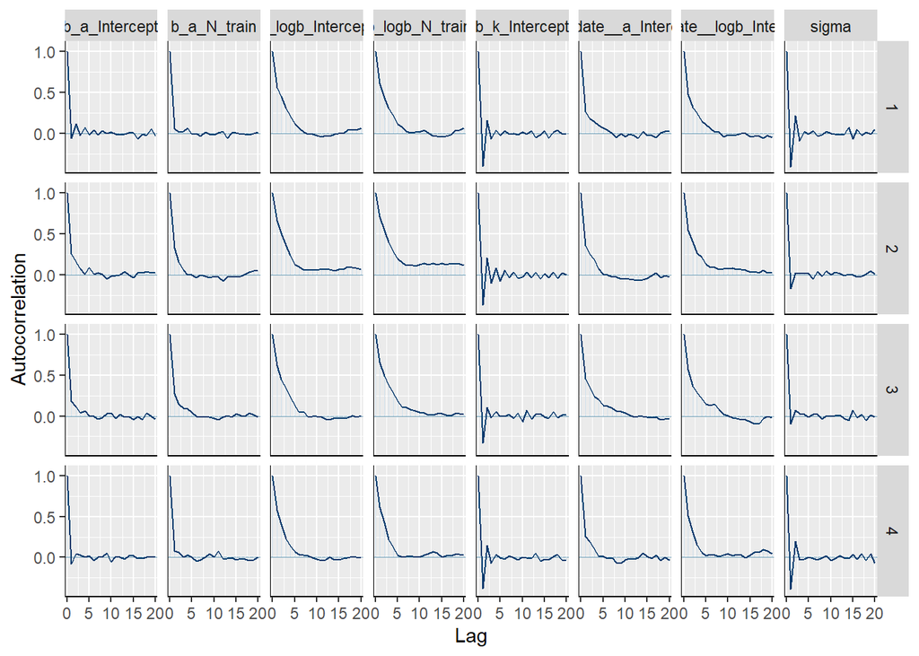

```r
parameters = c("b_a_Intercept","b_a_N_train","b_logb_Intercept",
               "b_logb_N_train","b_k_Intercept","sd_date__a_Intercept",
               "sd_date__logb_Intercept","sigma")
mcmc_acf(fit_exponential, pars = parameters)
```

Posterior density

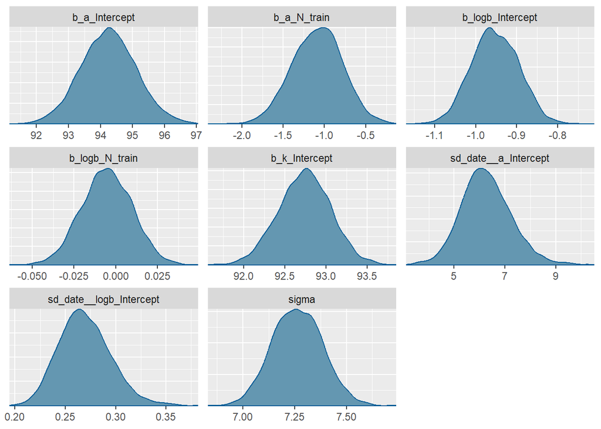

```r
mcmc_dens(fit_exponential, pars = parameters)
```

Traceplot after warmup

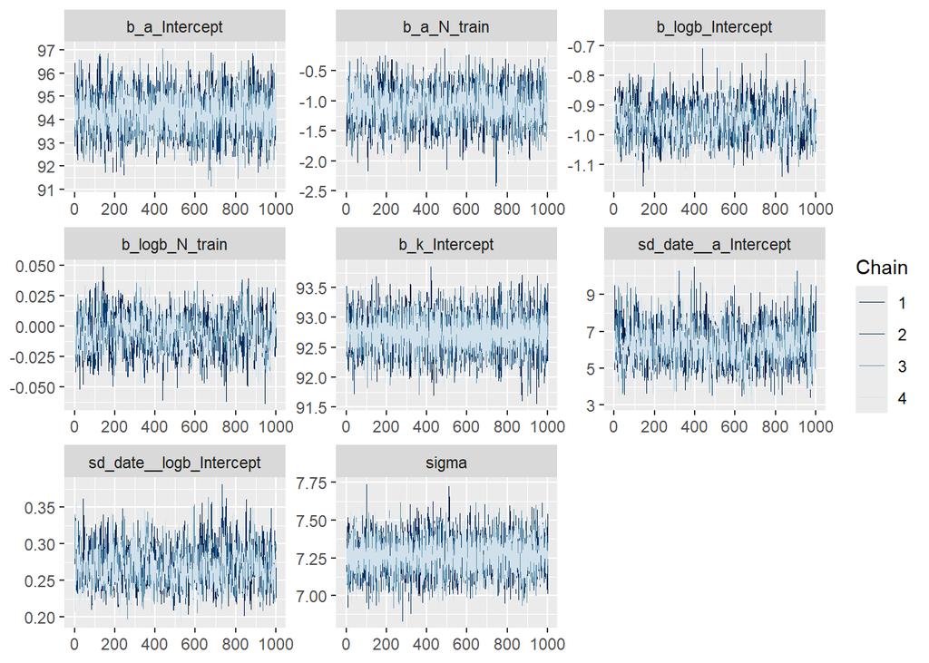

```r
mcmc_trace(fit_exponential, pars = parameters)
```